# Energy Data Hack [Hackathon CHALLENGE]

TEAM-BTECH

05/04/2021

```r
library(dplyr)
library(stringr)
library(corrplot)
library(cluster)
library(FactoMineR)
library(ggplot2)
library(psych)
library(factoextra)
library(kableExtra)
```

# **Importer les données**

Le travail effectué nécessite d’importer les données de Consommation annuelle d’électricité. C’est un ensemble de 6 fichiers excel qui contient des données sur des variables tant qualitatives que quantitatives. Nous avons lors de l’étape de traitement extrait les données en les sauvegardant dans un seul fichier txt dénommé **DTRawYear**. Pour cette partie, nous allons importer dans **R** les données afin d’effectuer les différentes analyses qui suivront :

```r
DTRawYear <- read.table("~/Hackathon2/DTRawYear.txt", quote="\"", comment.char="")
```

Nous pouvons voir un ensemble de $38$ variables sur nos données :

```r
colnames(DTRawYear)
```

```
##  [1] "n"                                "ministere_client_"
##  [3] "code_naf"                         "siren"
##  [5] "direction"                        "date_prev"
##  [7] "fournisseur_actuel_d_electricite" "nom_du_site"
##  [9] "adresse"                          "code_postal"
## [11] "ville"                            "siret"
## [13] "rae"                              "type_de_tarif"
## [15] "tension_de_raccordement"          "p_16"
## [17] "hph_17"                           "hch_18"
## [19] "hpe_19"                           "hce_20"
## [21] "hh_ejp_21"                        "p_ejp_22"
## [23] "p_23"                             "hph_24"
## [25] "hch_25"                           "hpe_26"
## [27] "hce_27"                           "hh_ejp_28"
## [29] "p_ejp_29"                         "p_30"
## [31] "hph_31"                           "hch_32"
## [33] "hpe_33"                           "hce_34"
## [35] "hh_ejp_35"                        "p_ejp_36"
## [37] "total"                            "electricite_100_verte_oui_non_"
```

```r
nrow(DTRawYear)
```

```
## [1] 3597
```

## **Présentation des données**

**DTRawYear** est un jeu de données contenant $3597$ observations sur $38$ variables. Les variables quantitatives dans le jeu de données constituent un ensemble de trois catégories :

**Puissances souscrites en kVA (ou en kW pour les Verts) :**

- $p\_16$ : Pointe Hiver
- $hph\_17$ : Heures Pleines Hiver
- $hch\_18$ : Heures Creuses Hiver
- $hpe\_19$ : Heures Pleines Eté
- $hce\_20$ : Heures Creuses Eté
- $hh\_ejp\_21$ : Heures Hiver
- $p\_ejp\_22$ : Hiver Pointe Mobile

**Puissances max atteintes en kW :**

- $p\_23$ : Pointe Hiver
- $hph\_24$ : Heures Pleines Hiver
- $hch\_25$ : Heures Creuses Hiver
- $hpe\_26$: Heures Pleines Eté
- $hce\_27$ : Heures Creuses Eté
- $hh\_ejp\_28$ : Heures Hiver
- $p\_ejp\_29$ : Hiver Pointe Mobile

**Consommations annuelles en kWh :**

- $p\_30$ : Pointe Hiver
- $hph\_31$ : Heures Pleines Hiver
- $hch\_32$ : Heures Creuses Hiver
- $hpe\_33$ : Heures Pleines Eté
- $hce\_34$ : Heures Creuses Eté
- $hh\_ejp\_35$ : Heures Hiver
- $p\_ejp\_36$ : Hiver Pointe Mobile

Les mesures de consommation pour les variables “**Heures Hiver**” et “**Hiver Pointe Mobile**” selon les 3 catégories n’ont pas été mesurées. Cela correspond donc à $100\%$ de données manquantes pour 6 variables : $hh\_ejp\_21, p\_ejp\_22, hh\_ejp\_28, p\_ejp\_29, hh\_ejp\_35 et p\_ejp\_36$.

Le code suivant nous a permis d’exclure ces 6 variables de la base de données :

```r
DTRawYear <- DTRawYear[, -c(21, 22, 28, 29, 35, 36)]
```

Ensuite, quelques variables comme : le $ministre\_client$, $nom\_du\_site$, le $rae$ et $electricite\_100\_verte\_oui\_non\_$ ont été retenues en plus des variables quantitatives pour notre jeu de données.

```r
dfRaw <- DTRawYear[, c("ministere_client_", "nom_du_site", "rae", colnames(DTRawYear)[16:30], "electricite_100_verte_oui_non_")]
```

Lors de l’importation des données, on observe que la variable $p\_16$ a été lue en tant que variable qualitative pourtant elle est de nature quantitavive, il convient donc de rectifier cela :

```r
str(dfRaw)
```

```
## 'data.frame':    3597 obs. of  19 variables:
##  $ ministere_client_             : Factor w/ 13 levels "Cour des Comptes",..: 1 9 9 9 9 11 11 11 11 11 ...
##  $ nom_du_site                   : Factor w/ 2320 levels "* HOTEL DES IMPOTS *",..: 393 987 986 1519 1520 1746 1747 1715 1715 1715 ...
##  $ rae                           : Factor w/ 3583 levels "05148190999189\n",..: 720 492 1245 815 879 1148 1170 818 2703 890 ...
##  $ p_16                          : Factor w/ 289 levels "0","1","10","100",..: 166 122 127 176 176 240 201 285 201 NA ...
##  $ hph_17                        : int  370 250 260 400 400 630 480 960 480 NA ...
##  $ hch_18                        : int  370 250 420 400 400 630 480 960 480 NA ...
##  $ hpe_19                        : int  370 250 420 400 400 630 480 960 480 NA ...
##  $ hce_20                        : int  370 250 420 400 400 630 480 960 480 NA ...
##  $ p_23                          : int  NA 274 248 349 236 351 445 899 513 NA ...
##  $ hph_24                        : int  NA 263 258 355 240 347 479 907 658 NA ...
##  $ hch_25                        : int  NA 266 398 193 129 320 236 639 490 NA ...
##  $ hpe_26                        : int  NA 201 247 318 307 370 456 849 371 NA ...
##  $ hce_27                        : int  NA 247 95 166 167 305 204 597 480 NA ...
##  $ p_30                          : num  251550 53078 32932 70310 63166 ...
##  $ hph_31                        : num  203076 183922 182755 361404 279655 ...
##  $ hch_32                        : num  623544 118733 227940 181747 156540 ...
##  $ hpe_33                        : num  421114 101281 126251 515001 430507 ...
##  $ hce_34                        : num  81446 55538 76738 230791 216507 ...
##  $ electricite_100_verte_oui_non_: Factor w/ 2 levels "NON","OUI": 2 2 2 2 2 2 2 2 2 2 ...
```

```r
dfRaw$p_16 <- as.numeric(dfRaw$p_16)
```

Parmi les $19$ covariables de notre base de données, il y a $15$ covariables qui contiennent des valeurs manquantes, dont $7$ en contiennent plus de $40\%$. En raison de la présence des données manquantes pour ces covariables, nous avons choisi d’exclure les individus pour lesquels il existe une information manquante. On parle de l’existence d’un biais de sélection dans la base de données. Une solution serait de recourir à des méthodes d’imputation ce qui permettrait de garder ces covariables dans l’analyse.

```r
missing = (dfRaw[, 4:18] %>% apply(2, is.na) %>%  apply(2, sum)/nrow(dfRaw))*100
missing = missing[order(missing, decreasing = TRUE)]
missing <- as.data.frame(missing)
missing <- data.frame(Var = row.names(missing), value = missing$missing)
missing$Var <- factor(missing$Var, levels = missing$Var)
missing$Group <- ifelse(missing$value<40, "<40", ">=40")
```

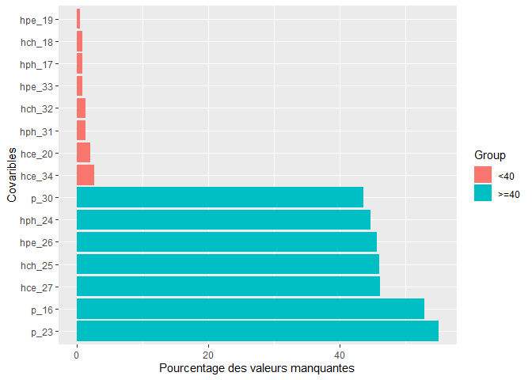

```r
g1 <- ggplot(missing) +  aes(x=Var, y=value, fill= Group) +  geom_bar(stat = "identity") +
  coord_flip() + labs(y = 'Pourcentage des valeurs manquantes', x = 'Covaribles')
g1
```

La fonction **na.omit()** permet d’exclure tous les éléments en ligne comportant des données manquantes. Nous disposons plus que $1108$ observations sur $19$ variables.

```r
dfRaw <- na.omit(dfRaw)
row.names(dfRaw) <- 1:nrow(dfRaw)
nrow(dfRaw)
```

```
## [1] 1108
```

# **Introduction**

L’étude réalisée dans ce livrable portera sur la base de données **dfRaw**. En effet, cette base associe aux différents points de livraison (Variable “**nom_du_site**”) en 2014 en France, une mesure de la consommation en électricité. En premier lieu, notre objectif est de regrouper par profil de consommation d’électricité ces différents points de livraison disponible. En Second lieu, par analyse identifier les activités exercées dans chacun de ces lieux (data center, lieu administratif, restauration, logement, etc…). Il s’agit ainsi d’une problématique de classification non supervisée ou encore clustering. Pour cela, une méthode de classification sera mise en avant : La Classification Ascendante Hierarchique (CAH).

# **Description des données**

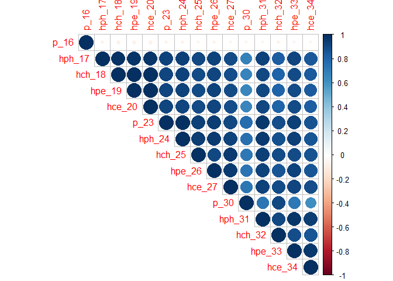

```r
M = cor(dfRaw[, 4:18]) # Matrice de corrélation
corrplot(M, type = 'upper')
```

# **La Classification Ascendante Hierarchique (CAH)**

Au regard de la forte corrélation existante entre nos données, il est intéressant d’effectuer bien avant une analyse factorielle avant de procéder au CAH de façon à supprimer l’information liaison des variables, laquelle est souvent considérée comme du bruit. Puisque nous ne travaillons que sur les variables quantitatives, l’analyse factorielle correspondante considérée est une ACP.

Avant de construire; l’ACP nous devons choisir de réduire ou non les données. Pour nos données, nous n’avons pas le choix la réduction est indispensable car les variables ont des unités différentes. La réduction permet d’accorder le même importance à chacune des variables dans le calcul de la distance entre individus. Ne pas réduire revient à donner plus d’importance aux variables ayant un grand écart-type. Ici, nous standardisons grâce à la focntion **PCA** qui réduit les données par défaut.

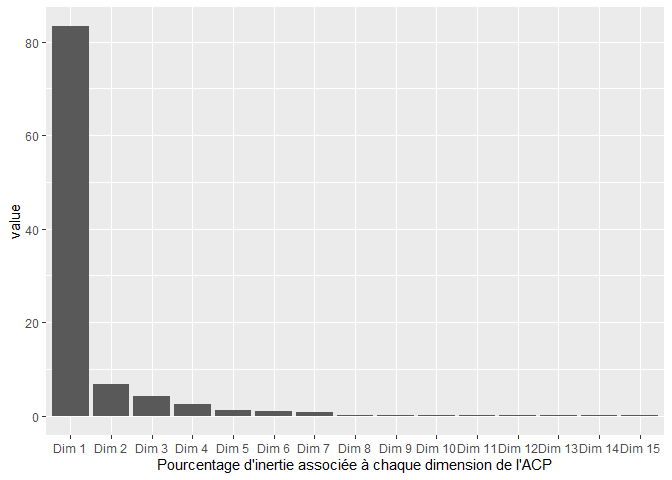

```r
res.pca <- PCA(dfRaw, quali.sup = c(1:3, 19), graph = F)
base <- data.frame(Var = paste("Dim", 1:nrow(res.pca$eig)), value = res.pca$eig[,2])
base$Var <- factor(base$Var, levels = base$Var)
g2 <- ggplot(base) +  aes(x=Var, y=value) +  geom_bar(stat = "identity") +
  labs(x = "Pourcentage d'inertie associée à chaque dimension de l'ACP")
g2
```

Nous recherchons alors une décroissance ou une cassure apparente sur le diagramme. Ici, nous pouvons analyser les deux premières dimensions. En effet, nous constatons après deux axes une décroissance regulière des inerties et nous observons un petit “saut” entre $2$ et $3$.

Le tableau des pourcentages d’inertie expliquée par chaque axe est donnée ci-dessous. Les deux premiers axes expriment $~90\%$ de l’inertie totale, c’est-à dire que $90\%$ de l’information de notre jeu de données est contenue dans les deux premières dimensions. Pour rester fidèle à l’information contenue dans les données, il importe de conserver un pourcentage d’inertie très élévée, l’objectif étant aussi de débruiter.Cela signifie aussi que nous resumons la diversité des profils de consommation d’éléctricité par deux dimensions.

```r
res.pca$eig[1:4, ]
```

```
##        eigenvalue percentage of variance cumulative percentage of variance
## comp 1 12.4961789              83.307859                          83.30786
## comp 2  0.9965019               6.643346                          89.95121
## comp 3  0.6367069               4.244713                          94.19592
## comp 4  0.3652183               2.434789                          96.63071
```

## **Description de la CAH**

La CAH a pour objectif de construire une hiérarchie sur les individus et se présente sous forme d’un dendogramme. Cette classification permet de regrouper des individus dans des classes les plus homogènes possibles à partir d’un jeu de données individus $\times$ variables. Cette méthode nécessite de choisr une distance entre individus, ou plus généralement une dissimilarité et un indice d’aggréation entre classes. La distance choisie est la distance euclidienne et l’indice d’aggrégation celui de Ward. l’indice d’aggrégation de Ward est un critère fondé sur l’inertie). Ce qui nous permet d’enchainer ACP et CAH.

La demarche est implementée dans la fonction **HCPC** du package **FactoMineR** pour les situations où on s’intéresse au criètre de Ward. On effectue ensuite la CAH sur les coordonnées des individus sur les $2$ premiers axes factoriels. L’argument $ncp=2$ de la fonction PCA permet de spécifier le nombre de composantes retenues.

```r
res.pca <- PCA(dfRaw, quali.sup = c(1:3, 19), ncp = 2, graph = F)
res.hcpc <- HCPC(res.pca, consol = FALSE, graph = FALSE)
```

## **Résultats obtenus**

Le dendrogramme permet de visualiser les regroupements successifs jusqu’à obtenir un unique cluster. Il est souvent pertinent de choisir le partitionnement correspondant au plus grand saut entre deux clusters consécutifs. Dans la sortie ci-dessous, il y a 6 lignes verticales traversées par la coupe, on en déduit que le nombre de clusters optimal est de 6. Ainsi, nous établissons six profils de consommateurs d’électricité.

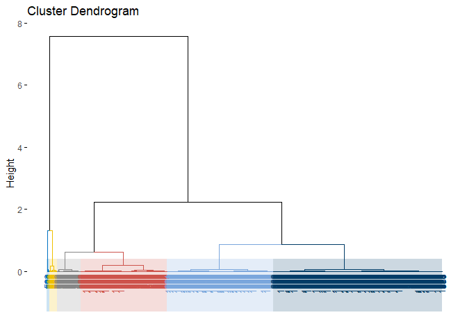

```r
fviz_dend(res.hcpc,
          cex = 0.7,                     # Label size
          palette = "jco",               # Color palette see
          rect = TRUE, rect_fill = TRUE, # Add rectangle around groups
          rect_border = "jco",           # Rectangle color
          labels_track_height = 0.8      # Augment the room for labels
)
```

- Pour afficher les données d’origine avec les affectations des clusters :

Dans le tableau ci-dessous, la dernière colonne contient les affectations des clusters.

```r
head(res.hcpc$data.clust, 4) %>% kable() %>% kable_styling()
```

| ministere_client_ | nom_du_site | rae | p_16 | hph_17 | hch_18 | hpe_19 | hce_20 | p_23 | hph_24 | hch_25 | hpe_26 | hce_27 | p_30 | hph_31 | hch_32 | hpe_33 | hce_34 | electricite_100_verte_oui_non_ | clust |
| --- | --- | --- | --- | --- | --- | --- | --- | --- | --- | --- | --- | --- | --- | --- | --- | --- | --- | --- | --- |
| Ministère de l’agriculture, de l’alimentation et de la forêt | DRAAF Champagne Ardennes | rae_30000430427991 | 122 | 250 | 250 | 250 | 250 | 274 | 263 | 266 | 201 | 247 | 53078 | 183922 | 118733 | 101281 | 55538 | OUI | 3 |
| Ministère de l’agriculture, de l’alimentation et de la forêt | DRAAF Bretagne | rae_30001440689341 | 127 | 260 | 420 | 420 | 420 | 248 | 258 | 398 | 247 | 95 | 32932 | 182755 | 227940 | 126251 | 76738 | OUI | 3 |
| Ministère de l’agriculture, de l’alimentation et de la forêt | MAAF VARENNE | rae_30000730176813 | 176 | 400 | 400 | 400 | 400 | 349 | 355 | 193 | 318 | 166 | 70310 | 361404 | 181747 | 515001 | 230791 | OUI | 3 |
| Ministère de l’agriculture, de l’alimentation et de la forêt | MAAF VAUGIRARD | rae_30000741251553 | 176 | 400 | 400 | 400 | 400 | 236 | 240 | 129 | 307 | 167 | 63166 | 279655 | 156540 | 430507 | 216507 | OUI | 3 |

- Affichons les variables quantitatives qui décrivent le plus chaque cluster :

```r
res.hcpc$desc.var$quanti
```

```
## $`1`
##            v.test Mean in category Overall mean sd in category  Overall sd
## p_16    24.066219        225.48414     152.5875       38.12027     86.9795
## p_30    -8.793198       4451.30867   29734.8682     4766.51343  82567.4485
## hch_32 -10.211696      19869.09302  102099.3321    14925.34504 231233.7387
## hce_34 -11.062118      20136.74841  109519.4856    15824.09506 232023.9949
## hch_25 -12.281907         22.63848     109.3718       22.76914    202.7860
## hph_31 -12.587967      41734.56025  160785.7067    20669.61457 271578.5678
## hce_27 -12.593656         20.38266      99.5731       20.83813    180.5670
## hpe_33 -12.596096      49413.79281  220042.0334    28773.54577 388984.6421
## p_23   -14.319116         34.37209     159.1245       29.32138    250.1787
## hph_24 -14.418152         36.25370     164.9630       30.22151    256.3409
## hpe_26 -14.494646         33.60888     154.9251       31.06049    240.3415
## hch_18 -15.136651         63.09937     204.3348       20.69931    267.9363
## hce_20 -15.184739         65.76956     209.3141       24.02746    271.4543
## hpe_19 -15.208005         65.32347     208.7717       22.09921    270.8572
## hph_17 -15.263016         61.59408     197.7292       19.93446    256.1223
##              p.value
## p_16   5.646964e-128
## p_30    1.453615e-18
## hch_32  1.757656e-24
## hce_34  1.915218e-28
## hch_25  1.132961e-34
## hph_31  2.459249e-36
## hce_27  2.288255e-36
## hpe_33  2.218556e-36
## p_23    1.662230e-46
## hph_24  3.978512e-47
## hpe_26  1.309754e-47
## hch_18  9.282210e-52
## hce_20  4.463332e-52
## hpe_19  3.129335e-52
## hph_17  1.348674e-52
##
## $`2`
##            v.test Mean in category Overall mean sd in category  Overall sd
## p_30    -3.754357      14374.37919   29734.8682    10885.44812  82567.4485
## hch_18  -4.519120        144.33557     204.3348       43.30508    267.9363
## hch_32  -4.534270      50145.30872  102099.3321    30270.22297 231233.7387
## hph_17  -4.606611        139.26510     197.7292       41.80460    256.1223
```

[output cut: 144 more lines]

```
##              p.value
## hch_32 4.403992e-135
## hph_31 4.152923e-114
## p_30   3.502744e-109
## hch_25 2.272830e-104
## p_23   4.615517e-102
## hpe_33 1.388780e-101
## hce_27  1.407987e-98
## hph_24  1.450245e-98
## hce_34  1.250886e-97
## hph_17  5.514933e-89
## hch_18  6.826365e-84
## hpe_26  2.930403e-82
## hpe_19  9.037105e-82
## hce_20  2.244951e-81
```

D’après les résultats ci-dessus, on peut voir que :

La variable $P\_16$ est associée de façon plus significative au cluster 2. Sa valeur moyenne est de $39.67$ kwh dans la cluster $2$, ce qui est inférieur à sa moyenne générale ($152.58$ kwh) pour tous les clusters.

- De même, pour afficher les dimensions principales qui sont les plus associées aux clusters :

```r
res.hcpc$desc.axes$quanti
```

```
## $`1`
##          v.test Mean in category  Overall mean sd in category Overall sd
## Dim.2  23.24438        0.8080524 -3.733241e-15      0.4391943  0.9982494
## Dim.1 -14.12028       -1.7382591  6.817852e-15      0.2451943  3.5349935
##             p.value
## Dim.2 1.621449e-119
## Dim.1  2.848447e-45
##
## $`2`
##           v.test Mean in category  Overall mean sd in category Overall sd
## Dim.1  -4.960422        -0.868896  6.817852e-15      0.4901593  3.5349935
## Dim.2 -26.605940        -1.316068 -3.733241e-15      0.3189050  0.9982494
##             p.value
## Dim.1  7.034034e-07
## Dim.2 5.794487e-156
##
## $`3`
##          v.test Mean in category  Overall mean sd in category Overall sd
## Dim.1  5.960192        1.1947582  6.817852e-15      0.9901457  3.5349935
## Dim.2 -2.973417       -0.1683163 -3.733241e-15      0.5243415  0.9982494
##            p.value
## Dim.1 2.519411e-09
## Dim.2 2.945037e-03
##
## $`4`
##          v.test Mean in category  Overall mean sd in category Overall sd
## Dim.1 11.202522         4.729253  6.817852e-15      1.1754202  3.5349935
## Dim.2  5.880661         0.701057 -3.733241e-15      0.4371983  0.9982494
##            p.value
## Dim.1 3.962883e-29
## Dim.2 4.086306e-09
##
## $`5`
##         v.test Mean in category Overall mean sd in category Overall sd
## Dim.1 16.92562         12.93792 6.817852e-15       3.234504   3.534993
##            p.value
## Dim.1 2.912768e-64
##
## $`6`
##         v.test Mean in category Overall mean sd in category Overall sd
## Dim.1 22.19009         29.56776 6.817852e-15        3.47375   3.534993
##             p.value
## Dim.1 4.281763e-109
```

```r
res.hcpc$desc.ind$para
```

```
## Cluster: 1
##        298        629        836        452       1039
## 0.03900358 0.05647273 0.06630926 0.07990828 0.08953232
## ------------------------------------------------------------
## Cluster: 2
##        872        850        684        940        234
## 0.01252714 0.02226696 0.06295860 0.07353332 0.09066936
## ------------------------------------------------------------
## Cluster: 3
##        509        491        487        918        543
## 0.02509444 0.06797737 0.07262520 0.09124262 0.09481810
## ------------------------------------------------------------
## Cluster: 4
##        761         13        485         26         70
## 0.08698091 0.14495971 0.17373922 0.23740775 0.24934304
## ------------------------------------------------------------
## Cluster: 5
##      725      764      520        7      554
## 1.207434 1.493216 1.511220 1.910789 1.929228
## ------------------------------------------------------------
## Cluster: 6
##        71        34        30       548        41
## 0.4168264 0.7128604 0.7855966 1.7919544 2.8267193
```

Pour chaque cluster, nous observons les $5$ individus les plus proches du centre du cluster qui sont affichés. La distance entre chaque individu et le centre du cluster est indiquée. Par exemple, les individus représentatifs de chaque cluster sont :

- Cluster 1 : les 5 points de livraison (variable **nom_du_site**)

```r
dfRaw[as.integer(names(res.hcpc$desc.ind$para$`1`)), c(1:3, 19)] %>% kable() %>% kable_styling()
```

|  | ministere_client_ | nom_du_site | rae | electricite_100_verte_oui_non_ |
| --- | --- | --- | --- | --- |
| 298 | Ministères économiques et financiers | IMPOTS - HOTEL D’ ISSOIRE | 30001710276049 | OUI |
| 629 | JUSTICE | MIN JUST - TRIBUNAL D’INSTANCE DE SANNOIS (215-02 | 30002150285804 | NON |
| 836 | Ministère de l’Intérieur | PREF POLICE S DIR MATER 1ER BU | 30002130307291 | NON |
| 452 | Ministères économiques et financiers | HOTELS DES IMPOTS | 30001210261045 | OUI |
| 1039 | Ministère de l’Intérieur | GENDARMERIE NATIONALE | 30001210311886 | NON |

- Cluster 2 : les 5 points de livraison (variable **nom_du_site**)

```r
dfRaw[as.integer(names(res.hcpc$desc.ind$para$`2`)), c(1:3, 19)] %>% kable() %>% kable_styling()
```

|  | ministere_client_ | nom_du_site | rae | electricite_100_verte_oui_non_ |
| --- | --- | --- | --- | --- |
| 872 | Ministère de l’Intérieur | CRS 15 | 30000140282202 | NON |
| 850 | Ministère de l’Intérieur | S.Z.T.I | 30000110363385 | NON |
| 684 | CULTURE | SCN ARCHIVES NATIONALES D’OUTRE MER | 30002521359407 | OUI |
| 940 | Ministère de l’Intérieur | HOTEL DE POLICE | 30001770104001 | NON |
| 234 | Ministères économiques et financiers | TRESORERIE GALE P L ETRANGER | 30001421309779 | OUI |

- Cluster 3 : les 5 points de livraison (variable **nom_du_site**)

```r
dfRaw[as.integer(names(res.hcpc$desc.ind$para$`3`)), c(1:3, 19)] %>% kable() %>% kable_styling()
```

|  | ministere_client_ | nom_du_site | rae | electricite_100_verte_oui_non_ |
| --- | --- | --- | --- | --- |
| 509 | JUSTICE | CENTRE DE DETENTION ECROUVES | 30000510282202 | NON |
| 491 | JUSTICE | MAISON D’ARRET LA TALAUDIERE | 30001980476923 | NON |
| 487 | JUSTICE | MAISON D’ARRET | 30000160137206 | NON |
| 918 | Ministère de l’Intérieur | CASERNE PASQUIER | 30002110340570 | NON |
| 543 | JUSTICE | MINISTERE DE LA JUSTICE | 30000710044738 | NON |

- Cluster 4 : les 5 points de livraison (variable **nom_du_site**)

```r
dfRaw[as.integer(names(res.hcpc$desc.ind$para$`4`)), c(1:3, 19)] %>% kable() %>% kable_styling()
```

|  | ministere_client_ | nom_du_site | rae | electricite_100_verte_oui_non_ |
| --- | --- | --- | --- | --- |
| 761 | INTERIEUR | ECOLE DE GENDARMERIE | 30001470385080 | NON |
| 13 | Ministères économiques et financiers | DSF TRESORERIE M M NANCY | 30000510303037 | OUI |
| 485 | JUSTICE | MAISON CENTRALE- ST MAUR | 30001760158747 | NON |
| 26 | Ministères économiques et financiers | TRESORERIE GENERALE | 30001610292018 | OUI |
| 70 | Ministères économiques et financiers | DISI PARIS CHAMPAGNE-NEMOURS | 30002210153937 | OUI |

- Cluster 5 : les 5 points de livraison (variable **nom_du_site**)

```r
dfRaw[as.integer(names(res.hcpc$desc.ind$para$`5`)), c(1:3, 19)] %>% kable() %>% kable_styling()
```

|  | ministere_client_ | nom_du_site | rae | electricite_100_verte_oui_non_ |
| --- | --- | --- | --- | --- |
| 725 | INTERIEUR | PREFECTURE DE PARIS ET IDF | 30000741467105 | NON |
| 764 | INTERIEUR | PREFECTURE ESSONNE BUREAU MOYE | 30002220440689 | NON |
| 520 | JUSTICE | PALAIS DE JUSTICE DE PARIS | 30000730676754 | NON |
| 7 | Ministère des affaires étrangères et du développement international | MINISTERE AFFAIRES ETRANGERES | 30000730180769 | OUI |
| 554 | CULTURE | SCN ARCHIVES NATIONALES 1-BJ9BHX | 50058465983280 | NON |

- Cluster 6 : les 5 points de livraison (variable **nom_du_site**)

```r
dfRaw[as.integer(names(res.hcpc$desc.ind$para$`6`)), c(1:3, 19)] %>% kable() %>% kable_styling()
```

|  | ministere_client_ | nom_du_site | rae | electricite_100_verte_oui_non_ |
| --- | --- | --- | --- | --- |
| 71 | Ministères économiques et financiers | DISI PARIS CHAMPAGNE - BUSSY | 30002210244615 | OUI |
| 34 | Ministères économiques et financiers | MEFI - DPMA - SEM M LA V - CENTRE INFORMATIQUE DES | 30002210338545 | NON |
| 30 | Ministères économiques et financiers | CITE ADMNISTRATIVE ETAT | 30001910545277 | OUI |
| 548 | M. SOCIAUX | MINISTERE TRAVAIL ET SECURITE | 30000740575631 | NON |
| 41 | Ministères économiques et financiers | MINEFE DPAEP LE MONTAIGNE | 30002241802210 | OUI |

Nous arrivons donc à mettre en évidence les profils de consommations correspondant aux points de livraisons disponibles.